# This HW has the following requirements.

### Which product performed so poorly?

```python
df.head(2)
```

| orderdate | orderid | orderpriority | orderquantity | sales | discount | shipmode | profit | unitprice | shippingcost | customername | customerstate | zipcode | region | customersegment | productcategory | productsub-category | productname | productcontainer | productbasemargin | shipdate |
| --- | --- | --- | --- | --- | --- | --- | --- | --- | --- | --- | --- | --- | --- | --- | --- | --- | --- | --- | --- | --- |
| 2010-08-26 | 3 | Low | 6 | 261.54 | 0.04 | Regular Air | -213.25 | 38.94 | 35.00 | Muhammed MacIntyre | New Jersey | 7514 | East | Small Business | Office Supplies | Storage & Organization | Eldon Base for stackable storage shelf, platinum | Large Box | 0.80 | 2010-09-02 |
| 2012-01-03 | 6 | Not Specified | 2 | 6.93 | 0.01 | Regular Air | -4.64 | 2.08 | 2.56 | Ruben Dartt | New York | 10457 | East | Corporate | Office Supplies | Scissors, Rulers and Trimmers | Kleencut® Forged Office Shears by Acme United ... | Small Pack | 0.55 | 2012-01-04 |

```python
df["productname"].nunique()
```

```
1263
```

```python
df.loc["2009"].groupby('productname')["profit"].sum().sort_values().head(20)
```

```
productname
Okidata Pacemark 4410N Wide Format Dot Matrix Printer                            -26610.81
Epson DFX-8500 Dot Matrix Printer                                                -23142.10
Canon imageCLASS 2200 Advanced Copier                                            -14830.99
Global High-Back Leather Tilter, Burgundy                                         -8778.90
Hoover Portapower™ Portable Vacuum                                                -7800.60
Tennsco Lockers, Gray                                                             -7521.09
Lexmark 4227 Plus Dot Matrix Printer                                              -6786.22
Bush Advantage Collection® Round Conference Table                                 -5649.23
Bush Westfield Collection Bookcases, Dark Cherry Finish, Fully Assembled          -4540.85
Lesro Sheffield Collection Coffee Table, End Table, Center Table, Corner Table    -4028.11
Hon 2090 “Pillow Soft” Series Mid Back Swivel/Tilt Chairs                         -3613.23
Hon 2111 Invitation™ Series Corner Table                                          -3519.07
Laminate Occasional Tables                                                        -3500.05
Polycom ViewStation™ ISDN Videoconferencing Unit                                  -3467.47
O'Sullivan 3-Shelf Heavy-Duty Bookcases                                           -3164.49
O'Sullivan Elevations Bookcase, Cherry Finish                                     -3103.63
Epson DFX5000+ Dot Matrix Printer                                                 -2944.05
BoxOffice By Design Rectangular and Half-Moon Meeting Room Tables                 -2928.96
Tennsco Industrial Shelving                                                       -2726.96
Eldon ClusterMat Chair Mat with Cordless Antistatic Protection                    -2584.43
Name: profit, dtype: float64
```

Out of 1263 products in this dataset, the products above are the top 20 worst products in terms of profit

## Let's focus on January 2009 and answer some questions below

### Which region performed so poorly?

```python
df.head()
```

| orderdate | orderid | orderpriority | orderquantity | sales | discount | shipmode | profit | unitprice | shippingcost | customername | customerstate | zipcode | region | customersegment | productcategory | productsub-category | productname | productcontainer | productbasemargin | shipdate |
| --- | --- | --- | --- | --- | --- | --- | --- | --- | --- | --- | --- | --- | --- | --- | --- | --- | --- | --- | --- | --- |
| 2010-08-26 | 3 | Low | 6 | 261.5400 | 0.04 | Regular Air | -213.250 | 38.94 | 35.00 | Muhammed MacIntyre | New Jersey | 7514 | East | Small Business | Office Supplies | Storage & Organization | Eldon Base for stackable storage shelf, platinum | Large Box | 0.80 | 2010-09-02 |
| 2012-01-03 | 6 | Not Specified | 2 | 6.9300 | 0.01 | Regular Air | -4.640 | 2.08 | 2.56 | Ruben Dartt | New York | 10457 | East | Corporate | Office Supplies | Scissors, Rulers and Trimmers | Kleencut® Forged Office Shears by Acme United ... | Small Pack | 0.55 | 2012-01-04 |
| 2011-05-28 | 32 | High | 15 | 140.5600 | 0.04 | Regular Air | -128.380 | 8.46 | 8.99 | Liz Pelletier | Ohio | 44197 | Central | Corporate | Technology | Computer Peripherals | Imation 3.5 IBM Diskettes, 10/Box | Small Pack | 0.79 | 2011-05-29 |
| 2011-05-28 | 32 | High | 24 | 1761.4000 | 0.09 | Delivery Truck | -1748.560 | 70.89 | 89.30 | Liz Pelletier | Ohio | 44197 | Central | Corporate | Furniture | Tables | KI Conference Tables | Jumbo Box | 0.72 | 2011-05-29 |
| 2011-05-28 | 32 | High | 23 | 160.2335 | 0.04 | Regular Air | -85.129 | 7.99 | 5.03 | Liz Pelletier | Ohio | 44197 | Central | Corporate | Technology | Telephones and Communication | Bell Sonecor JB700 Caller ID | Medium Box | 0.60 | 2011-05-30 |

```python
df.loc["2009-01"].groupby('region')["profit"].sum().sort_values()
```

```
region
East      -12084.3320
South       -463.1045
Central     2516.9330
West        3374.3950
Name: profit, dtype: float64
```

In january 2009, the east region made the least profit, with -12k in profit, which is a deficit. In addition, the south region also had a 463 dollar deficit

### Which zipcode areas performed so poorly?

```python
df.loc["2009-01"].groupby('zipcode')["profit"].sum().sort_values().head(10)
```

```
zipcode
10501   -16253.6800
35077   -11769.1700
21230    -2073.8980
5544     -2041.2800
23111    -1271.7100
83810     -948.7100
35751     -851.0900
85001     -815.7900
62999     -742.6585
6439      -704.9240
Name: profit, dtype: float64
```

These are the top 10 worst preforming zipcodes for January 2009 in terms of profit

### Which product category performed so poorly?

```python
df.loc["2009-01"].groupby('productcategory')["profit"].sum().sort_values()
```

```
productcategory
Technology        -10547.7010
Office Supplies    -1516.0075
Furniture           5407.6000
Name: profit, dtype: float64
```

Technology and office supplies both drew deficits for january 2009

### Which productsub-category performed so poorly?

```python
df.loc["2009-01"].groupby('productsub-category')["profit"].sum().sort_values()
```

```
productsub-category
Copiers and Fax                  -8496.2700
Office Machines                  -2435.8600
Storage & Organization           -2093.5100
Tables                           -2010.3200
Scissors, Rulers and Trimmers    -1767.6000
Bookcases                        -1196.0300
Pens & Art Supplies                 -3.2100
Paper                               39.2600
Computer Peripherals               117.1000
Labels                             195.1100
Telephones and Communication       267.3290
Envelopes                          299.7000
Binders and Binder Accessories     730.5425
Appliances                        1083.7000
Office Furnishings                2293.4800
Chairs & Chairmats                6320.4700
Name: profit, dtype: float64
```

Copiers, fax, office machines, storage, tables, scissors, rulers, trimmers, bookcases, and art supplies all drew negative profit

### Which product performed so poorly?

```python
df.loc["2009-01"].groupby('productname')["profit"].sum().sort_values().head(10)
```

```
productname
Polycom ViewStation™ ISDN Videoconferencing Unit                                    -16253.68
Canon imageCLASS 2200 Advanced Copier                                               -11769.17
High Speed Automatic Electric Letter Opener                                          -1759.58
Tennsco Lockers, Gray                                                                -1666.88
Bush Westfield Collection Bookcases, Dark Cherry Finish, Fully Assembled             -1390.53
Laminate Occasional Tables                                                           -1233.39
Bravo II™ Megaboss® 12-Amp Hard Body Upright, Replacement Belts, 2 Belts per Pack     -948.71
Euro Pro Shark Stick Mini Vacuum                                                      -807.89
TimeportP7382                                                                         -693.33
Carina 42"Hx23 3/4"W Media Storage Unit                                               -684.78
Name: profit, dtype: float64
```

The polycom viewstation created about 16k of losses

# Your Own Questions

```python
# Q1 Which product created the most profit overall?
```

```python
df.groupby("productname")["profit"].sum().sort_values(ascending=False).head(1)
```

```
productname
Global Troy™ Executive Leather Low-Back Tilter    79284.78
Name: profit, dtype: float64
```

```python
# Q2 Relationship between unitprice and total sales
```

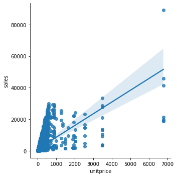

```python
sns.lmplot(x="unitprice", y="sales", data=df)
```

```python
# Q3 Which state generated the most profit overall
```

```python
df.groupby("customerstate")["profit"].sum().sort_values(ascending=False).head(1)
```

```
customerstate
Maryland    114643.8955
Name: profit, dtype: float64
```

# Your storytelling below